# Severity pipeline-simulated data

2023-05-24

Epiverse severity (and underreporting) pipeline illustrated with data from 100-days workshop simulated scenario data.

```r
Linelist_group3 <- read_csv("Data/Linelist_group3.csv")
head(Linelist_group3)
```

```
## # A tibble: 6 × 13
##   case_name      case_type ct_value gender   age onset_date hospitalisation_date
##   <chr>          <chr>        <dbl>  <dbl> <dbl> <date>     <date>
## 1 Samiha Morgan  confirmed     25.5      1    NA 2023-01-01 NA
## 2 Dazhane Gonza… suspected     NA        1    64 NA         NA
## 3 Davis Mercer   confirmed     24.8      0    34 2023-01-05 NA
## 4 Jamie Ficklin  confirmed     21.4     NA    10 2023-01-03 NA
## 5 Jonathan Irons confirmed     24.1      0    15 2023-01-06 NA
## 6 Shanelle Dixon confirmed     27.4      1    NA 2023-01-08 NA
## # ℹ 6 more variables: death_date <date>, date_first_contact <date>,
## #   date_last_contact <date>, report_date <date>, island_group <chr>,
## #   occupation <chr>
```

### Task 1: Identify and correct inconsistencies and errors in the data

The package linelist was used to create a `linelist` object through the `make_linelist()` function, which adds tags to df columns, that represent relevant variables in epidemiological analysis. Current tags can be checked using the function `tags()`. Currently (June 2023) it is necessary to install the development version of the package:

```r
#pak::pak("epiverse-trace/linelist")
library(linelist)
```

```r
linelist_3 <- make_linelist(Linelist_group3,
                            id = "case_name", date_onset = "onset_date",
                            date_reporting = "report_date",
                            date_admission = "hospitalisation_date",
                            date_death = "death_date", gender = "gender",
                            age = "age", location = "island_group",
                            occupation = "occupation")
tags(linelist_3)
```

```
## $id
## [1] "case_name"
##
## $date_onset
## [1] "onset_date"
##
## $date_reporting
## [1] "report_date"
##
## $date_admission
## [1] "hospitalisation_date"
##
## $date_death
## [1] "death_date"
##
## $gender
## [1] "gender"
##
## $age
## [1] "age"
##
## $location
## [1] "island_group"
##
## $occupation
## [1] "occupation"
```

The function `validate_linelist()` was used to check that column formats fit the class of the corresponding tags. This is useful to perform checks on the data to ensure that it is in the right format before conducting any further analyses.

*Won’t knit when using this function because it generates an error if classes are incorrect*

Multiple errors were detected, and subsequently corrected thanks to this check:

```r
linelist_3$onset_date <- as.Date(linelist_3$onset_date, format = "%Y-%m-%d")
linelist_3$report_date <- as.Date(linelist_3$report_date, format = "%Y-%m-%d")
linelist_3$hospitalisation_date <- as.Date(linelist_3$hospitalisation_date, format = "%Y-%m-%d")
linelist_3$death_date <- as.Date(linelist_3$death_date, format = "%Y-%m-%d")
linelist_3$gender <- as.character(linelist_3$gender)

validate_linelist(linelist_3)
```

```
##
## // linelist object
## # A tibble: 553 × 13
##    case_name     case_type ct_value gender   age onset_date hospitalisation_date
##    <chr>         <chr>        <dbl> <chr>  <dbl> <date>     <date>
##  1 Samiha Morgan confirmed     25.5 1         NA 2023-01-01 NA
##  2 Dazhane Gonz… suspected     NA   1         64 NA         NA
##  3 Davis Mercer  confirmed     24.8 0         34 2023-01-05 NA
##  4 Jamie Ficklin confirmed     21.4 <NA>      10 2023-01-03 NA
##  5 Jonathan Iro… confirmed     24.1 0         15 2023-01-06 NA
##  6 Shanelle Dix… confirmed     27.4 1         NA 2023-01-08 NA
##  7 Analecia Mil… confirmed     24   1         73 2023-01-09 NA
##  8 Kessa Graves  confirmed     28   1         NA 2023-01-09 NA
##  9 Courtney Fra… suspected     NA   1         NA 2023-01-06 NA
## 10 Skylar Blazek probable      NA   1         66 2023-01-07 NA
## # ℹ 543 more rows
## # ℹ 6 more variables: death_date <date>, date_first_contact <date>,
## #   date_last_contact <date>, report_date <date>, island_group <chr>,
## #   occupation <chr>
##
## // tags: id:case_name, date_onset:onset_date, date_reporting:report_date, date_admission:hospitalisation_date, date_death:death_date, gender:gender, age:age, location:island_group, occupation:occupation
```

The `lost_tags_action()` was used to determine the message that the user receives when tags are lost in the subsequent steps of the analysis, e.g., when subsetting data. Also, the `get_lost_tags_action()` is used to check which action had been set- which can be changed throughout the analysis.

```r
lost_tags_action("warning")
```

```
## Lost tags will now issue a warning.
```

```r
get_lost_tags_action()
```

```
## [1] "warning"
```

The package cleanepi was used to clean linelist data. This package will include multiple functions, to remove duplicate entries, check IDs and verify that they comply with the expected format, automatically standardise dates, or calculate the age of cases included in the linelist.

*At the moment, it is not possible to use `linelist` tags to remove duplicates across columns*

```r
library(cleanepi)
linelist3_clean <- cleanepi(linelist_3, remove.duplicates = T, duplicates.from = c("case_name","ct_value","age","hospitalisation_date","date_first_contact","report_date","occupation","case_type","gender","onset_date","death_date","date_last_contact","island_group"), clean.col.names = T)
```

```
##
## Cleaning the column names
## Removing duplicated records
```

## Task 2: What is the CFR?

In this section, the packages datadelay, epiparameter, and quickfit are used to estimate the case fatality rate of disease, while correcting the calculation to account for censoring of cases.

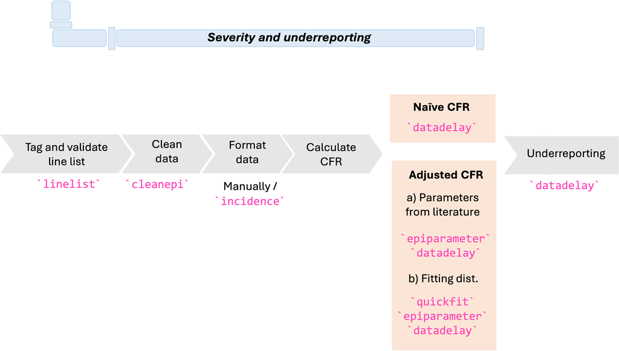

To be able to use `datadelay`, it is necessary to first format the data as a dataframe with the number of cases, deaths, and dates of death, for which the package `incidence2` was used.

*Issue raised on `datadelay` to facilitate the input of data so that users don’t have to change from a long to wide format using several lines of code*

```r
library(incidence2)
daily_cases_deaths <- incidence2::incidence(linelist3_clean,c("onset_date","death_date")) |> complete_dates()
daily_cases_deaths <- pivot_wider(daily_cases_deaths, names_from = count_variable, values_from = count)
names(daily_cases_deaths)[2:3]=c("deaths","cases")
daily_cases_deaths <- daily_cases_deaths[c(1,3,2)]
daily_cases_deaths <- as.data.frame(daily_cases_deaths)
#Adding location
daily_cases_deaths$location <- "Philippines"
```

The function `estimate_static()` was used to estimate the overall value of the CFR in this scenario. The argument `correct = TRUE/FALSE` allows the user to correct the CFR estimation, based on the distribution of the onset-death delay. The function `format_output()` provides a nicely formatted summary of the CFR value and its 95% CI. On the following example, these functions are first used to estimate the naive CFR:

```r
library(datadelay)
# Naive, static CFR:
n_static_CFR <- estimate_static(daily_cases_deaths, correct_for_delays = F, location = "location")
format_output(n_static_CFR, estimate_type = "severity")
```

```
##      Location                      Estimate
## 1 Philippines 6.60% (95% CI: 4.53% - 9.23%)
```

The corrected overall CFR was calculated by importing the onset-death delay distribution for Ebola from the `epiparameter` package:

```r
library(epiparameter)

# Loading delay distribution:
onset_to_death_ebola <- epiparameter::epidist_db(
  disease = "Ebola Virus Disease",
  epi_dist = "onset_to_death",
  author = "WHO_Ebola_Response_Team")
```

```
## Using WHO Ebola Response Team (2015) <10.1056/NEJMc1414992> PMID: 25539446.
## To retrieve the short citation use the 'get_citation' function
```

```r
# Corrected, static CFR:
c_static_CFR <- estimate_static(daily_cases_deaths, epi_dist = onset_to_death_ebola, correct_for_delays = T, location = "location")

format_output(c_static_CFR, estimate_type = "severity")
```

```
##      Location                      Estimate
## 1 Philippines 6.70% (95% CI: 4.70% - 9.30%)
```

*The `estimate_static` function can also be used to compare the CFR estimates in different areas when the input dataset has the death counts per day and also per affected region* <- not true at the moment

```r
daily_cases_deaths_location <- incidence2::incidence(linelist3_clean,c("onset_date","death_date"), groups = "island_group") |> complete_dates()
daily_cases_deaths_location <- pivot_wider(daily_cases_deaths_location, names_from = count_variable, values_from = count)
daily_cases_deaths_location <- daily_cases_deaths_location[c(1,4,3,2)]
names(daily_cases_deaths_location)[2:3]=c("cases","deaths")
#daily_cases_deaths_location <- as.data.frame(daily_cases_deaths_location)
```

```r
n_static_CFR_region <- estimate_static(daily_cases_deaths_location, correct_for_delays = F, location = "island_group")
format_output(n_static_CFR_region, estimate_type = "severity")
```

```
##   Location                      Estimate
## 1    Luzon 6.60% (95% CI: 4.53% - 9.23%)
## 2 Mindanao 6.60% (95% CI: 4.53% - 9.23%)
## 3  Visayas 6.60% (95% CI: 4.53% - 9.23%)
```

The function `estimate_time_varying()` provides an estimation of the CFR over time. Similarly to the example above, this estimation can be naive or corrected.

*Further, the function `plot_data_and_CFR()` helps to easily visualise the data along with the estimated CFR: <Is this function gone??*

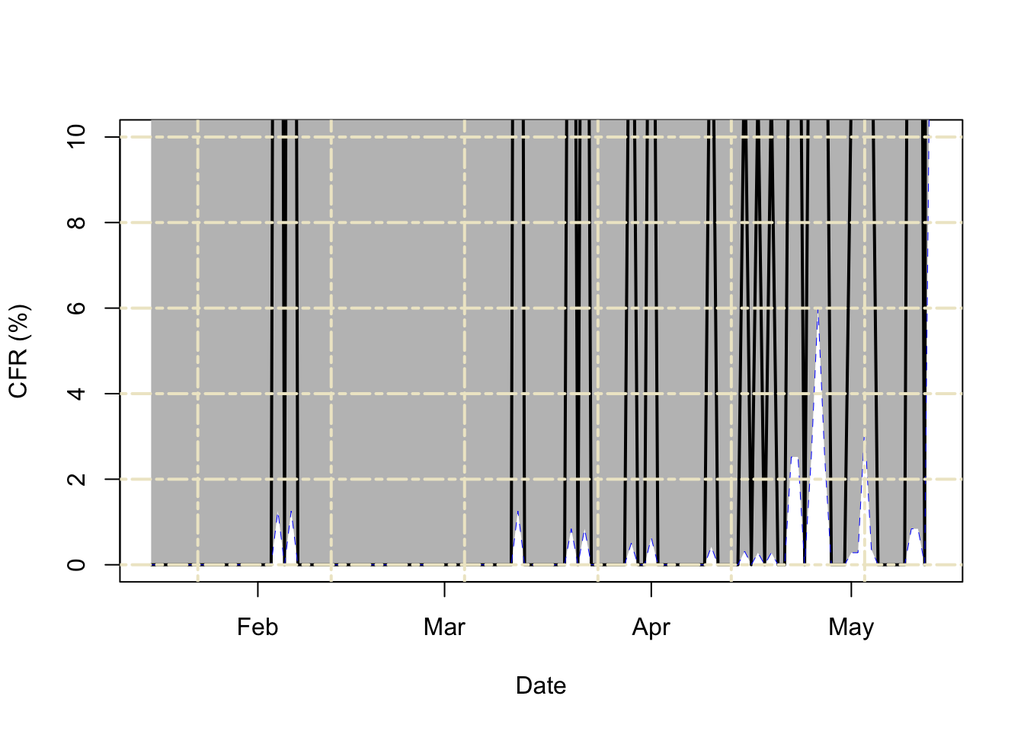

```r
n_rolling_CFR <- estimate_time_varying(daily_cases_deaths, epi_dist = onset_to_death_ebola, correct_for_delays = FALSE)

c_rolling_CRF <- estimate_time_varying(daily_cases_deaths, epi_dist = onset_to_death_ebola, correct_for_delays = T)

plot_time_varying(c_rolling_CRF)
```

Because the disease in this scenario is Reston Ebolavirus, a pathogen that (to our knowledge) does not affect humans, another option is to fit a distribution to the data ourselves, as there are no estimates for this variant in humans. This is applicable to any other emerging disease. In the following example, `fitdistrplus` and `quickfit` were used to fit a probability distribution to the onset-death delay, so that in can be used in the corrected CFR estimation.

First, data was formatted and a histogram was produced to visualise the distribution of deaths:

```r
onset_to_death <- linelist3_clean[,c(6,8)]
```

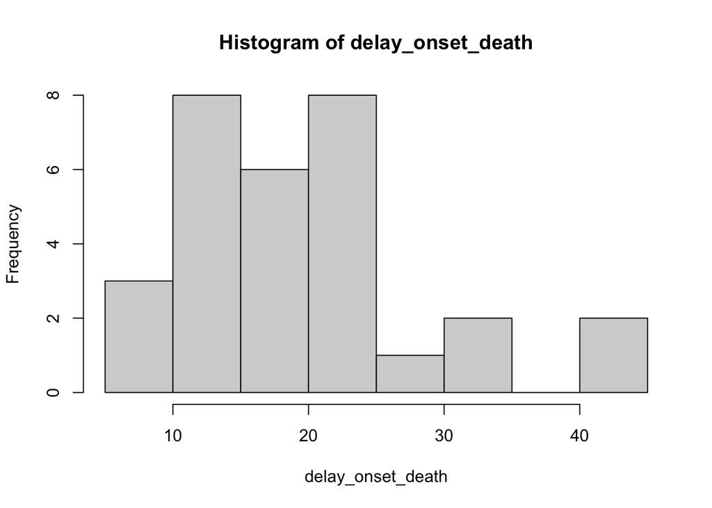

```r
onset_to_death <- na.omit(onset_to_death)
delay_onset_death <- as.numeric(onset_to_death$death_date - onset_to_death$onset_date)
hist(delay_onset_death)
```

Then, different distributions were fitted and compared:

```r
library(fitdistrplus)
fit_lnorm_od <- fitdist(delay_onset_death, "lnorm")
fit_gamma_od <- fitdist(delay_onset_death, "gamma")
fit_weibull_od <- fitdist(delay_onset_death, "weibull")

#Comparing AIC and BIC
fit_comparison_od <- data.frame(distribution = c("Weibull", "Gamma", "Lognormal"),
  AIC = c(fit_weibull_od$aic, fit_gamma_od$aic, fit_lnorm_od$aic),
  BIC = c(fit_weibull_od$bic, fit_gamma_od$bic, fit_lnorm_od$bic))

fit_comparison_od
```

```
##   distribution      AIC      BIC
## 1      Weibull 216.7368 219.5392
## 2        Gamma 212.9877 215.7900
## 3    Lognormal 211.4719 214.2743
```

To compare the fit of probability distributions, the function `multfitdist()`, from `quickfit` can also be used, which provides the AIC, BIC, and the log-likelihood:

```r
library(quickfit)
multi_fitdist(
  data = delay_onset_death,
  models = c("lnorm", "gamma", "weibull"))
```

```
##    models    loglik      aic      bic
## 1   lnorm -103.7360 211.4719 214.2743
## 2   gamma -104.4938 212.9877 215.7900
## 3 weibull -106.3684 216.7368 219.5392
```

Next, this distribution was converted to an `epidist` object, so that it could be used with `datadelay`’s functions. This involved using the function `extract_param()` to extract the distribution’s parameters. These parameters, along with the summary statistics of the scenario data, are used to create an `epidist` object with the function `epidist()`:

```r
library(epiparameter)

summary(delay_onset_death)
```

```
##    Min. 1st Qu.  Median    Mean 3rd Qu.    Max.
##    8.00   12.00   18.50   19.43   21.75   45.00
```

```r
extract_param(
  type = "percentiles",
  values = c(12, 21.75),
  distribution = "lnorm",
  percentiles = c(0.25, 0.75)) #values- meanlog: 2.78, sdlog: 0.44
```

```
## Stochastic numerical optimisation used.
## Rerun function multiple times to check global optimum is found
```

```
##   meanlog     sdlog
## 2.7822605 0.4408597
```

```r
summary_stats <- create_epidist_summary_stats(mean = 19.43, median = 18.5, quantiles = c(q_25=12,q_75=21.75))

restonebv_o_d <- epidist(disease = "ebola", pathogen = "reston_ebv",
                 epi_dist = "onset_to_death", prob_distribution = "lnorm",
                 prob_distribution_params = c(meanlog=2.78, sdlog=0.44),
                 summary_stats = summary_stats)
```

```
## Citation cannot be created as either author, year or DOI is missing
```

Lastly, the CFR was recalculated using `datadelay` with custom distribution parameters:

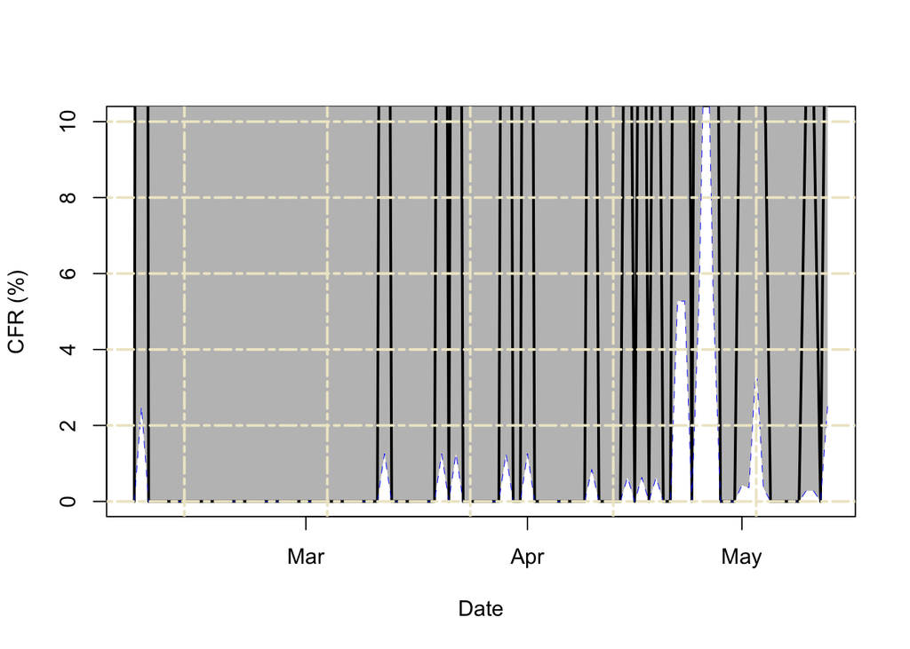

```r
rEbv_rolling_CFR <- estimate_time_varying(daily_cases_deaths, correct_for_delays = T, epi_dist = restonebv_o_d)

plot_time_varying(rEbv_rolling_CFR)
```

### Task 3: Estimation of proportion of ascertained cases

The function `known_outcomes()` from `datadelay` allows the user to estimate the expected number of individuals with known outcomes, given the case and death data collected during an outbreak.

*What does the outcome mean? what is the number in the new column, expected no. of cases with known outcomes??*

*How does the known_outcomes() function fit with the estimate_underreporting() function?*

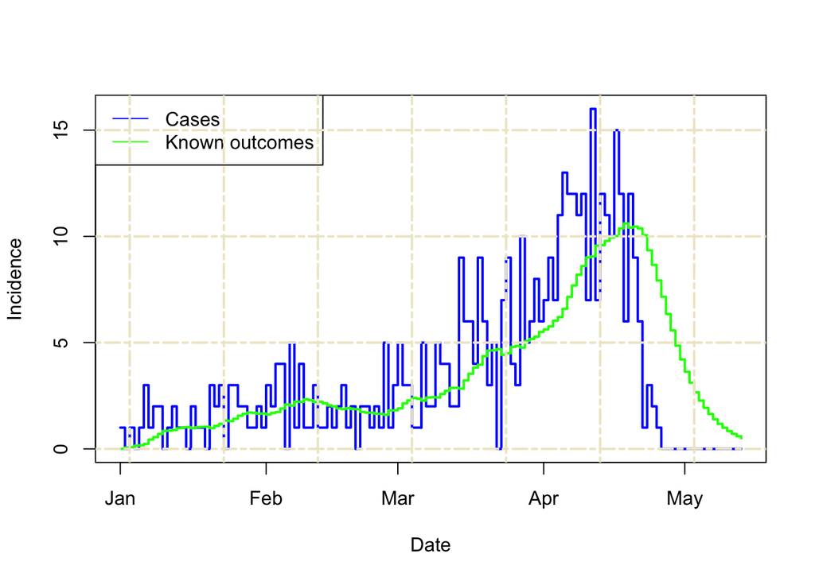

```r
ebola_known_outcomes <- known_outcomes(daily_cases_deaths, epi_dist = onset_to_death_ebola)

plot_known_outcomes(ebola_known_outcomes)
```